# distribuciones_notables_continuas

Christian Limbert Paredes Aguilera

14/1/2022

# La distribución uniforme

### Función de densidad

Una v.a. continua $X$ diremos que tiene una distribución uniforme sobre el intervalo real $(a,b)$, si su función de densidad es
$$f_X(x) = \left\{\begin{array}{rcl}
\dfrac{1}{b-a} & si & a<x<b \\
0&&\mbox{en cualquier otro caso}
\end{array}\right.$$

Comprobar que el área entre $f_X$ y la horizontal vale $1$.
$$\int_{-\infty}^{\infty} f_X(x)\; dx = \int_a^b \dfrac{1}{b-a}\; dx = \dfrac{x}{b-a} \bigg|_a^b = 1$$

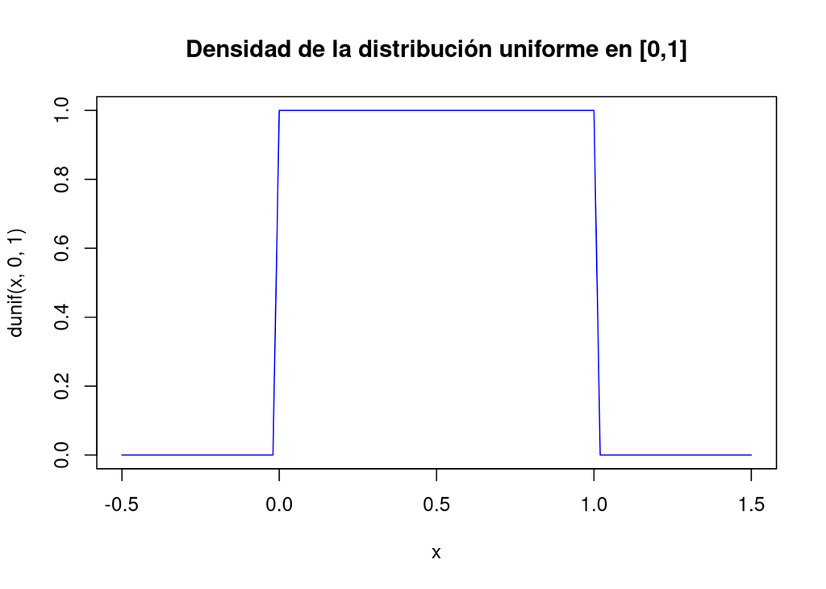

```r
curve(dunif(x,0,1),xlim=c(-0.5,1.5),col="blue",
      main="Densidad de la distribución uniforme en [0,1]")
```

### Función de distribución

$$f_X(x) = \left\{\begin{array}{rcl}
0&si&x\leq a \\
\dfrac{x-a}{b-a} & si & a<x<b\\
1&si&b\leq x
\end{array}\right.$$

Demostración.-

Si $x\leq a$ entonces,
$$f_X(x) = \int_{-\infty}^x f(t)\; dt = \int_{-\infty}^x 0 \; dt$$

Si $a<x<b$ entonces,
$$f_X(x) = \int_{-\infty}^x f(t)\; dt = \int_{-\infty}^a 0\; dt + \int_{a}^x \dfrac{1}{b-a}\; dt = \dfrac{x-a}{b-a}$$

Si $x\geq b$ entonces,

$$F_X(x) = \int_{-\infty}^{x} f(t)\; dt = \int_a^{b} \dfrac{1}{b-a}\; dt = \dfrac{t}{b-a}\bigg|_a^{b} = \dfrac{b}{b-a} - \dfrac{a}{b-a} = 1$$

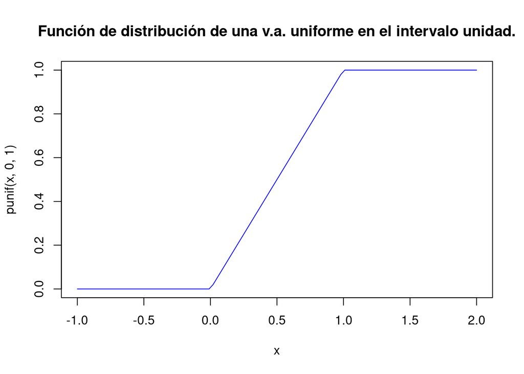

```r
curve(punif(x,0,1),xlim=c(-1,2),col="blue",
      main="Función de distribución de una v.a. uniforme en el intervalo unidad.")
```

## Esperanza y varianza

### Varianza

$$E(X^2) = \int_{-\infty}^{\infty} x^2 f_X(x)\; dx = \int_a^b x^2\dfrac{1}{b-a}\; dx = \dfrac{x^3}{3(b-a)}\bigg|_a^b = \dfrac{b^2+ab+a^2}{3}$$
$$Var(X) = E(X^2)-E^2(X) = \dfrac{b^2 + ab + a^2}{3}-\left(\dfrac{b+a}{2}\right)^2 = \dfrac{(b-a)^2}{12}$$

## Cambio lineal de la uniforme

Si $X$ sigue una distribución $U(a,b)$ entonces $Z=\dfrac{x-a}{b-a}$ sigue una distribución $U(0,1)$

### Propiedades cambio lineal distribución uniforme

Sea $X$ una v.a. $U(a,b)$

Si $scale\neq 0$ y $loc$ son dos constantes reales entonces

- Si $scale>0$ $T=scale\cdot X + loc$ sigue una ley $U(scale \cdot a + loc, scale\cdot b + loc)$
- Si $scale<0$ $T=scale\cdot X + loc$ sigue una ley $U(scale \cdot b + loc, scale\cdot a + loc)$

Supongamos que $X$ sigue una ley $U(a,b)$, que $scale>0$ y que $T=\dfrac{X-loc}{scale}$

Así tenemos que
$$F_X(X) = P(X\leq x) = \left\{\begin{array}{rcl}
0&si&x\leq a\\
\dfrac{x-a}{b-a}&si&x\leq x \leq b\\
1&si&b\leq x\\
\end{array}\right.$$

Si $T$ es una $U(scale\cdot a + loc, scale\cdot b + loc)$ su función de distribución será:
$$F_T(x) = P(scale\cdot X + loc\leq t) = P\left(X\leq \dfrac{t-loc}{scale}\right) = F_X \left(X=\dfrac{t-loc}{scale}\right) =$$

$$=\left\{\begin{array}{rcl}
0&si&\frac{t-loc}{scale}\leq a\\
\dfrac{\frac{t-loc}{scale}}{b-a}&si&a\leq \frac{t-loc}{scale} \leq b\\
1&si&b\leq \frac{t-loc}{scale}\\
\end{array}\right. =
\left\{\begin{array}{lcl}
0&si&t\leq scale\cdot a + loc\\
\dfrac{t-(scale\cdot a + loc)}{scale\cdot b + loc - (scale\cdot a + loc)}&si&scale\cdot a + loc \leq t \leq scale\cdot b + loc\\
1&si&scale\cdot b+loc\leq t\\
\end{array}\right.$$

## Distribución uniforme en R

Sea $X$ una v.a. y $U(-1,1)$. Como es habitual, aunque ahora la variable es continua, las funciones de densidad y de distribución son

```r
dunif(x=0.5,min=-1,max=1)
```

```
## [1] 0.5
```

```r
punif(q=0.5,min = -1, max = 1)
```

```
## [1] 0.75
```

```r
runif(n=5,min=-1,max=1)
```

```
## [1] -0.56910217  0.32896129 -0.50651531 -0.08012987 -0.53645099
```

por defecto dunif(x,max=0,max=1)

```r
dunif(x=0.5)
```

```
## [1] 1
```

```r
punif(q=0.5)
```

```
## [1] 0.5
```

```r
runif(n=5)
```

```
## [1] 0.6066706 0.9342993 0.9705692 0.6967223 0.1455541
```

## Cuantiles de variables aleatorias

Si $X$ es una v.a. con dominio $D_X$ y $0<q<1$ llamaremos cuantil de orden $q$ al menor valor perteneciente al dominio $x_q\subset D_X$ tal que
$$P(X\leq x_q)\geq q.$$

Por ejemplo si $X$ es una $B(5,0.5)$

```r
pbinom(0:5,5,0.5)
```

```
## [1] 0.03125 0.18750 0.50000 0.81250 0.96875 1.00000
```

```r
qbinom(c(0.25,0.5,0.75),5,0.5)
```

```
## [1] 2 2 3
```

```r
qbinom(c(0.3,0.6,0.8),5,0.5)
```

```
## [1] 2 3 3
```

Como $X$ sigue una $B(5,0.5)$, recordemos que $D_X = {0,1,2,\ldots,n=5}$, y que su función de distribución es
$$F_X(x) = P(X\leq x) = \left\{\begin{array}{rcl}
0&si&\\
0.03125&si&x<0\\
0.18750&si&0\leq x < 1\\
0.50000&si&2\leq x < 2\\
0.81250&si&3\leq x < 4\\
0.96875&si&4\leq x < 5\\
1.00000&si&5\leq x\\
\end{array}\right.$$

El cuantil $q=0.3$ es el primer valor $x\in D_X$ tal que $F_X(x)=P(X\leq x_{0.3}) \geq 0.3$ así que el primer valor es $x_{0.3}=2$ ya que $F_X(2)=P(X\leq 2) = 0.5 \geq 0.3$

En general podemos considerar que $F^{-1}$ es la función que nos da los cuantiles (es decir si $F^{-1}(p)$ de más de un valor tomaremos como anti-imagen el valor más pequeño que esté dentro del dominio $D_X$).

# Distribución exponencial

## Distribución del tiempo entre dos eventos Poisson

Supongamos que tenemos un proceso Poisson con parámetro $\lambda$ en una unidad de tiempo.

Sea $t>0$ entonces
$$P(T>t) = P(\mbox{cero eventos en el intervalo(0,t]}) = P(N_t=0) = \dfrac{(\lambda t)^0}{0!}e^{-\lambda t} = e^{-\lambda t}$$

### Función de distribución

Tomando complementarios, la función de distribución de $T$ será
$$F_T(t) = P(T\leq t) = 1 - P(X>t) = \left\{\begin{array}{rcl} 0 & si & t\leq 0 \\ 1 - e^{-\lambda t} & si & t>0\end{array}\right.$$

luego, derivando respecto de $t$ se tiene,
$$f_t(t) = \left\{\begin{array}{rcl} \lambda \cdot e^{-\lambda t} & si & t>0 \\ 0 & si & t\leq 0 \end{array}\right.$$

La exponencial de denota por $Exp(\lambda)$.

La poisson es la distribución discreta que cuenta el número de eventos por unidad de tiempo y la exponencial es la versión continua que cuenta el tiempo entre dos sucesos de poisson.

### Propiedad de falta de memoria

Sea $X$ una v.a. Exp() entonces
$$P(X>s+t | X>s) = P(X>t)\; \mbox{para todo}\; s,t \in \mathbb{R}$$

Demostración.- Si $X$ es una variable aleatoria $Exp(\lambda)$ tenemos que
$$P(X>x) = 1-P(X\leq x) = 1 - (1-e^{-\lambda\cdot x}) = e^{-\lambda\cdot x}\; \mbox{para todo}\; x>0$$

$$P(X>s+t | X>s) = \dfrac{P({X>s+t}\cap {X>s})}{P(X>s)}=\dfrac{P(X>s+t)}{P(X>s)}=\dfrac{e^{-\lambda(s+t)}}{e^{-\lambda\cdot s}}=\dfrac{e^{-\lambda} \cdot s \cdot e^{-\lambda\cdot t}}{e^{-\lambda\cdot s}}=e^{-\lambda\cdot t}$$

### Esperanza

$$E(X)=\dfrac{1}{\lambda}$$

### Varianza

$$Var(X) = \dfrac{1}{\lambda^2}$$

## Distribución exponencial en R

La función de densidad, de distribución y la generación aleatoria de valores de una exponencial, se puede obtener en R con:

```r
# función de densidad pudee dar mas de 1
dexp(0.001, rate=3)
```

```
## [1] 2.991013
```

```r
# función de distribución
pexp(0.5,rate=3)
```

```
## [1] 0.7768698
```

```r
rexp(10,3)
```

```
##  [1] 0.0899544028 0.7816951540 0.1390991518 0.3538137019 0.1922555366
##  [6] 0.0008061177 0.3455399663 0.2771373037 0.1317110202 0.5702379805
```

#### gráfica

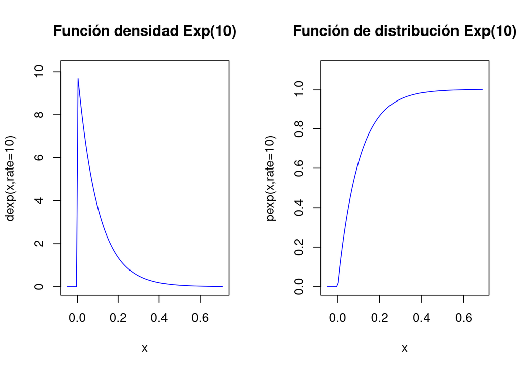

```r
{lambda=10
par(mfrow=c(1,2))
curve(dexp(x,rate=lambda),xlim=c(-0.05,round(qexp(0.99,rate=lambda,2),2)+0.25),
      ylim=c(0,dexp(0,lambda)+0.1),col="blue",
      main=paste0("Función densidad Exp(",lambda,")"),
      ylab=paste0("dexp(x,rate=",lambda,")"))
curve(pexp(x,rate=lambda),xlim=c(-0.05,qexp(0.999,10)),ylim=c(0,1.1),col="blue",
      main=paste0("Función de distribución Exp(",lambda,")"),
      ylab=paste0("pexp(x,rate=",lambda,")"))
par(mfrow=c(1,1))}
```

# Distribución normal

### Función de densidad

Distribución normal o de Gauss diremos que una v.a. $X$ sigue una ley normal de parámetros $\mu$ y $\sigma^2$ y la denotaremos por $N(\mu,\sigma)$si tiene por función de densidad
$$f_X(x) = \dfrac{1}{\sqrt{2\pi \sigma^2}}e^{-\frac{1}{2}\cdot \left(\frac{x-\mu}{\sigma}\right)^2}$$
para todo $x\in \mathbb{R}$.

La v.a. normal con $\mu=0$ y $\sigma=1$ recibe el nombre de normal estándar y se suele denotar por la letra $Z$ normal $N(0,1)$.

### Gráfica

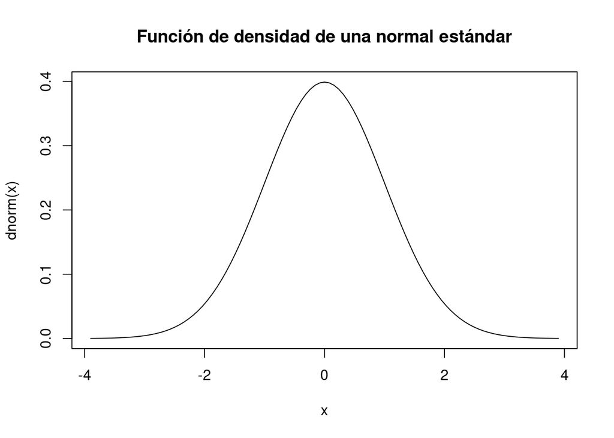

```r
curve(dnorm(x),main = "Función de densidad de una normal estándar", xlim = c(-3.9,3.9))
```

### Función de distribución $N(0,1)$

Su función de distribución es, como sabemos:

$$F(X) = \int_{-\infty}^x \dfrac{1}{\sqrt{2\pi\sigma^2}}e^{-\frac{1}{2}\left(\frac{t-\mu}{\sigma}\right)^2}\; dt$$

### Esperanza

$$E(X)=\mu$$

## Distribución normal en R

Para una $X\sim N(\mu=1,\sigma=2)$ la función de densidad $f_X(2)$ se puede calcular como:

```r
dnorm(2,mean=1,sd=2)
```

```
## [1] 0.1760327
```

y la función de distribución $F_X(2)=P(X\leq 2)$ como

```r
pnorm(2,mean=1,sd=2)
```

```
## [1] 0.6914625
```

El cuantil $x_{0.95}$ es el valor que cumple $P(X\leq x_{0.95}) = 0.95$ como

```r
qnorm(0.95,mean=1,sd=2)
```

```
## [1] 4.289707
```

Y la generación aleatoria de valores egún $X$ como

```r
rnorm(n=5,mean=1,sd=2)
```

```
## [1]  2.997860  3.797537  1.509001  2.013666 -1.009448
```

## Propiedades de la distribución normal

La función de densidad de la distribución normal tiene las siguientes propiedades:

- La función $f_X$ es continua.
- $\displaystyle\int_{-\infty}^\infty \dfrac{1}{\sqrt{2\pi \sigma^2}} \cdot e^{-\frac{1}{2}\cdot \left(\frac{x-\mu}{\sigma}\right)^2}\; dx = 1$ (Propiedad de todas las densidades).
- $f(\mu-x) = f(\mu-x).$
- $F(\mu-x) = 1-F(\mu+x).$
- $\lim\limits_{x\to +\infty} f(x) = \lim\limits_{x\to - \infty} = 0$ es decir tiene asíntota horizontal a derecha e izquierda.
- $f$ es estrictamente creciente si $x<\mu$ y decreciente si $x>\mu$.
- Alcanza el máximo en $x=\mu$ y en este punto vale $f(\mu)=\dfrac{1}{\sqrt{2\pi \sigma^2}}$.
- Tiene dos puntos de inflexión en $x=\mu+\sigma$ y en $x=\mu-\sigma$.

## Cómo calcular cuantiles de la normal

$p_{0.9}=50$ y $p_{0.15} = 25$

$0.9=P(X\leq 50)=P\left( Z\leq\dfrac{50-\mu}{\sigma} \right) \Longrightarrow \dfrac{50-\mu}{\sigma} = 1.28$

$0.15=P(X\leq 25)=P\left(Z\leq\dfrac{25-\mu}{\sigma}\right) \Longrightarrow \dfrac{50-\mu}{\sigma} = 1.04$

- cuando vale $\mu$

$\mu=36.2$

- Cuanto vale $\sigma$

$\sigma=10.77$

- $p_{0.4}$

$P(X\leq P_{0.4}) = 0.4 \Longrightarrow P\left(>\leq \dfrac{p_{0.4}-36.2}{10.77}\right) = 0.4 \Longrightarrow \dfrac{p_{0.4}-36.2}{10.77} = -0.26 \Longrightarrow p_{0.4} = 33.4$

## Transformaciones lineales de variables aleatorias normales

### Propiedades

Sea $X$ una variable $N(\mu,\sigma)$ entonces la variable $Y=aX+b$ con $a\neq 0,\; b\in \mathbb{R}$ tiene distribución $N(a\mu + b, |a| \cdot \sigma)$

En particular si $X$ sigue una $N(\mu,\sigma)$ , tomando $a=\dfrac{1}{\sigma}$ y $b=\dfrac{-\mu}{\sigma}$ obtenemos la tipificación o estandarización de la v.a.
$$Z=\dfrac{X-\mu}{\sigma}$$

se sitribuye $N(0,1)$, es decir $E(X)=0$ y $Var(X) = 1$.

Esta propiedad es muy útil, ya que utilizándola sólo necesitaremos tabular la $N(0,1)$

Si $Z$ sigue una distribución $N(0,1)$ diremos que $Z$ sigue una distribución normal estándar.

Por lo tanto podemos calcular cualquier distribución normal desde la distribución normal estándar:
$$F_X(x)=F_Z\left(\dfrac{x-\mu}{\sigma}\right)$$

Sea $Z$ una $N(0,1)$

Como en este caso $\mu=0$ y $\sigma=1$ tenemos que algunas de las propiedades anteriores se simplifican incluso más:

- De $f_X(\mu-x) = f_X(\mu+x)$ obtenemos $f_Z(-x) =f_Z(x)$.
- De $F_X(\mu-x) = 1- F_X(\mu+x)$ obtenemos $F_Z(-x)= 1- F(x)$.

. Dado $\delta>0,$ $P(-\delta\leq Z \leq \delta) = F_Z(\delta) - F_Z(-\delta) = F_Z(\delta) - (1-F_Z(\delta)) = 2\cdot F_Z(\delta)-1$

### Ejercicio

Sea una distribución $N(0,1)$ calcular las siguientes probabilidades en función de $F_Z.$

$P(-4\leq Z \leq 4) = F_Z(4)-F_Z(-4) = F_Z(4) - (1-F_Z(4)) = 2F_Z(4) - 1$

$P(-2\leq Z\leq 2) =F_Z(2) - F_Z(-2) = 2F_Z(2) - 1$

$P(Z\leq -2) = F_Z(-2) = 1-F_Z(2)$

$P(Z\leq 2) F_Z(2)$

$P(Z\geq 2) = 1 - P(Z<2) = 1 - F_Z(2)$

$P(Z>2) = 1 - P(Z\leq 2) = 1-F_Z(2)$

$P(Z=2) = 0$

$P(Z\geq -2) = 1-P(Z<-2)=1-F_Z(-2)=1-(1-F_Z(2))=F_Z(2)$

## Relación entre una normal y la normal estándar.

### Propiedades

- Si $X$ es una normal $N(\mu, \sigma)$ es una variable tipificada, es decir, $Z=\dfrac{X-\mu}{\sigma}$ es una $N(0,1)$ entonces:

$$P(X\leq x) = P\left(\dfrac{X-\mu}{\sigma}\leq \dfrac{x-\mu}{\sigma}\right) = F_Z\left(\dfrac{x-\mu}{\sigma}\right)$$

- Cuando tengamos un intevalo

$$\begin{array}{rcl}
P(a<X<b)&=&P\left(\dfrac{a-\mu}{\sigma}<\dfrac{X-\mu}{\sigma}<\dfrac{b-\mu}{\sigma}\right)\\
&=&\left(\dfrac{a-\mu}{\sigma}<Z<\dfrac{b-\mu}{\sigma}\right)\\
&=&F_Z\left(\dfrac{b-\mu}{\sigma}\right) - F_Z\left(\dfrac{a-\mu}{\sigma}\right)\\
\end{array}$$

- Si $\delta>0$, $P(\mu-\sigma\leq X\leq \mu+\sigma) = 2F_Z\left(\dfrac{\delta}{\sigma}\right)-1$

#### Ejercicio

Sea $X$ una normal con media 2 y varianza 4, calcular:

$P(1<X<2) = P\left(\dfrac{1-2}{2}<\dfrac{Z-\mu}{\sigma}<\dfrac{2-2}{2}\right) = -\dfrac{1}{2}<Z<0$